# Глава 3. Классификация

## Оглавление

- MNIST
- Обучение двоичного классификатора
- Показатели производительности
  - Измерение правильности с ипользованием перекрестной проверки
  - Матрица неточностей
  - Точность и полнота
  - Соотношение точность/полнота
  - Кривая ROC
- Многоклассовая классификация
- Анализ ошибок
- Многозначная классификация
- Многовыходовая классификация

Самыми распрастраненными задачами обучения с учитилем являются **регрессия (прогнозирование значений)** и **классификация (прогнозирование классов)**.

## MNIST

MNIST (Mixed National Institute of Standards and Technology - смешанный набор данных НАционального интситута стандартов и технологий США). В машинном обучении принято считать как ("Hello, World!") в программировании.

Библиотека scikit-learn представляет много вспомогательных функций для загрухки популярных наборов данных.

```python
from sklearn.datasets import load_digits
import pandas as pd
import matplotlib.pyplot as plt
%matplotlib inline


mnist = load_digits()

# from sklearn.datasets import fetch_openml
# mnist = fetch_openml('mnist_784', version=1, cache=True, as_frame=False)
```

```python
mnist.keys()
```

```
dict_keys(['data', 'target', 'frame', 'feature_names', 'target_names', 'images', 'DESCR'])
```

Набор данных имеет состав:

- ключ DESCR, описывающий набор данных;
- ключ data, содержащий массив с одной строкой на образец и одним столбцом на признак;
- ключ target, содержащий массив с метками;

```python
X, y = mnist['data'], mnist['target']
print('X: ', X.shape)
print('y: ', y.shape)
```

```
X:  (1797, 64)
y:  (1797,)
```

```python
pd.DataFrame(mnist.data).head()
```

|  | 0 | 1 | 2 | 3 | 4 | 5 | 6 | 7 | 8 | 9 | ... | 54 | 55 | 56 | 57 | 58 | 59 | 60 | 61 | 62 | 63 |
| --- | --- | --- | --- | --- | --- | --- | --- | --- | --- | --- | --- | --- | --- | --- | --- | --- | --- | --- | --- | --- | --- |
| 0 | 0.0 | 0.0 | 5.0 | 13.0 | 9.0 | 1.0 | 0.0 | 0.0 | 0.0 | 0.0 | ... | 0.0 | 0.0 | 0.0 | 0.0 | 6.0 | 13.0 | 10.0 | 0.0 | 0.0 | 0.0 |
| 1 | 0.0 | 0.0 | 0.0 | 12.0 | 13.0 | 5.0 | 0.0 | 0.0 | 0.0 | 0.0 | ... | 0.0 | 0.0 | 0.0 | 0.0 | 0.0 | 11.0 | 16.0 | 10.0 | 0.0 | 0.0 |
| 2 | 0.0 | 0.0 | 0.0 | 4.0 | 15.0 | 12.0 | 0.0 | 0.0 | 0.0 | 0.0 | ... | 5.0 | 0.0 | 0.0 | 0.0 | 0.0 | 3.0 | 11.0 | 16.0 | 9.0 | 0.0 |
| 3 | 0.0 | 0.0 | 7.0 | 15.0 | 13.0 | 1.0 | 0.0 | 0.0 | 0.0 | 8.0 | ... | 9.0 | 0.0 | 0.0 | 0.0 | 7.0 | 13.0 | 13.0 | 9.0 | 0.0 | 0.0 |
| 4 | 0.0 | 0.0 | 0.0 | 1.0 | 11.0 | 0.0 | 0.0 | 0.0 | 0.0 | 0.0 | ... | 0.0 | 0.0 | 0.0 | 0.0 | 0.0 | 2.0 | 16.0 | 4.0 | 0.0 | 0.0 |

5 rows × 64 columns

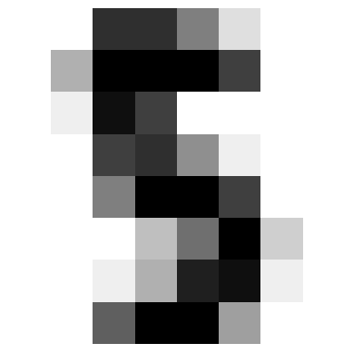

```python
# взглянем на любую цифру
some_digit = X[74]
some_digit_image = some_digit.reshape(8, 8)
plt.imshow(some_digit_image, cmap=plt.cm.binary, interpolation='nearest')
plt.axis('off')
plt.show()
```

```python
y[74]
```

```
5
```

```python
import matplotlib as mpl
import matplotlib.pyplot as plt
import numpy as np

def plot_digits(instances, images_per_row=10, **options):
    size = 8
    images_per_row = min(len(instances), images_per_row)
    images = [instance.reshape(size,size) for instance in instances]
    n_rows = (len(instances) - 1) // images_per_row + 1
    row_images = []
    n_empty = n_rows * images_per_row - len(instances)
    images.append(np.zeros((size, size * n_empty)))
    for row in range(n_rows):
        rimages = images[row * images_per_row : (row + 1) * images_per_row]
        row_images.append(np.concatenate(rimages, axis=1))
    image = np.concatenate(row_images, axis=0)
    plt.imshow(image, cmap = mpl.cm.binary, **options)
    plt.axis("off")
```

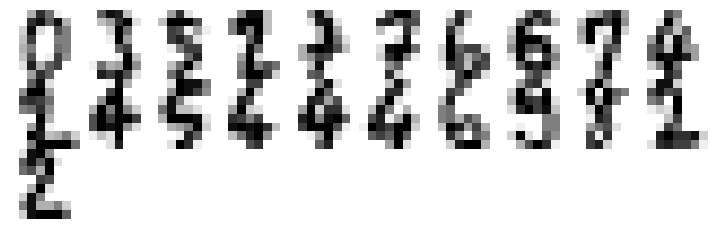

```python
plt.figure(figsize=(9,9))
example_images = np.r_[X[:1200:60], X[1300:306:60], X[306:600:590]]
plot_digits(example_images, images_per_row=10)
plt.show()
```

MNIST уже разделен на обучающий набор и испытательный набор

```python
X_train, X_test, y_train, y_test = X[:1200], X[1200:], y[:1200], y[1200:]
```

Перетасуем общий набор: это гарантирует, что все блоки перекрестной проверки будут похожими. Тасование набора может оказаться неудачной идеей в ряде контекстов, например, при работе с данными временных рядов.

```python
import numpy as np

shuffle_index = np.random.permutation(1200)
X_train, y_train = X_train[shuffle_index], y_train[shuffle_index]
```

## Обучение двоичного классификатора

**Двоичный классификатор (binary classifier)** проводит различия между двумя классами, например, "пятерка" и "не пятерка". Создадим целевые векторы для этой задачи классификации.

```python
y_train_5 = (y_train == 5)
y_test_5 = (y_test == 5)
```

Хорошим местом для старта будет классификатор на основе метода **стохастического градиентного спуска (Stochastic Gradient Descent - SGD)**, который применяет класс SGDClassifier из Scikit-Learn. **Преимущество данного метода** - эффективно обрабатывает очень крупный набор данных. SGD использует обучающие образцы независимым образом по одному за раз, что делает SGD подходящим для *динамического обучения*. Класс *SGDClassifier* полагается на неупорядочность во время обучения.

```python
# Создадим экземпляр SGDClassifier

from sklearn.linear_model import SGDClassifier

sgd_clf = SGDClassifier(max_iter=5, tol=-np.infty, random_state=42)
sgd_clf.fit(X_train, y_train_5)
```

```
SGDClassifier(max_iter=5, random_state=42, tol=-inf)
```

```python
sgd_clf.predict([some_digit])
```

```
array([ True])
```

На следующем шаге нужно *оценить производительность модели*.

## Показатели производительности

Оценка классификатора часто значительно сложнее, чем оценка регрессора.

### Измерение правильности с ипользованием перекрестной проверки

Scikit-Learn предлагает в готовом виде **перекрестную проверку (cross-validation)** (но также можно реализовать самостоятельно). Следующий программный код делает приблизительно то же, что и функция _cross_val_score_ из Scikit-Learn.

```python
from sklearn.model_selection import StratifiedKFold
from sklearn.base import clone

skfolds = StratifiedKFold(n_splits=3)
for train_index, test_index in skfolds.split(X_train, y_train_5):
    clone_clf = clone(sgd_clf)
    X_train_folds = X_train[train_index]
    y_train_folds = y_train_5[train_index]
    X_test_fold = X_train[test_index]
    y_test_fold = y_train[test_index]

    clone_clf.fit(X_train_folds, y_train_folds)
    y_pred = clone_clf.predict(X_test_fold)
    n_correct = sum(y_pred == y_test_fold)
```

Используем функцию _cross_val_score_ для оценки модели SGDClassifier с применением перекрестной проверки по *К* блокам, имея три блока.

```python
from sklearn.model_selection import cross_val_score

cross_val_score(sgd_clf, X_train, y_train_5, cv=3, scoring='accuracy')
```

```
array([0.9975, 0.9775, 0.995 ])
```

**Правильность (accuracy, коэффициент корректных прогнозов)** часто используемая оценка качества модели классификации на первых порах.

```python
# взглянем на очень глупый классификатор, который просто относит все изображения к классу "не пятерка"
from sklearn.base import  BaseEstimator

class Never5Classifier(BaseEstimator):
    def fit(self, X,y=None):
        pass
    def predict(self, X):
        return np.zeros((len(X), 1), dtype=bool)
```

```python
never_5_clf = Never5Classifier()
cross_val_score(never_5_clf, X_train, y_train_5, cv=3, scoring='accuracy')
```

```
array([0.8925, 0.9075, 0.8925])
```

Правильность модели почти 90%, потому что изображений являющимимся пятерками около 10%. Это демонстрирует причину, по которой правильность обычно не считается предпочтительным показателем производительности для классификаторов, особенно когда работа заключается с **ассиметричными наборами данных**.

### Матрица неточностей

Гораздо лучший способ оценки производительности классификатора предусматривает просмотр **матрицы неточностей (confusion matrix)**. Идея заключается в том, чтобы подсчитать сколько раз образцы класса А были отнесены к классу В.

Для расчета матрицы неточностей сначала понадобится иметь набор прогнозов, чтобы их можно было сравнить с фактическими целями. Можно использовать фенкцию _cross_val_predict()_

```python
from sklearn.model_selection import cross_val_predict

y_train_pred = cross_val_predict(sgd_clf, X_train, y_train_5, cv=3)
```

Как и _cross_val_score()_, функция _cross_val_predict()_ выполняет перекрестную проверку по К блокам, но вместо сумм очков оценки она возвращает прогнозы, выработанные на каждом испытательном блоке.

Все готово для матрицы неточностей. Используя функцию **confusion_matrix()** создадим ее.

```python
from sklearn.metrics import confusion_matrix

confusion_matrix(y_train_5, y_train_pred)
```

```
array([[1071,    6],
       [   6,  117]])
```

Каждая строка в матрице неточностей предоставялет **фактический класс**, каждый столбец - **спрогнозированный класс**. Первая строка матрицы учитывает неискомый класс **(отрицательный класс (negative class))**: не искомый класс корректно классифицирован от искомого **(истинно отрицательные классификации (true negative - TN))**, отсавшиеся ошибочно классифицированны как искомый **(ложноположительные классификации (false positive - FP))**. Вторая строка матрицы учитывает искомый класс **(положительный класс (positive class))**: искомый ошибочно классифицирован как нескомый класс **(ложноотрицательные классификации (false negative - FN))**, оставшиеся корректно классифицированы как искомый класс **(истинно положительные классификации (true positive - TP))**. Безупречный классификатор имел бы только истинно положительные и истино отрицательные классификации.

Более сжатой метрикой является интересная метрика - аккуратность положительных классификаций, которая называется **точность (precision)** классификатора

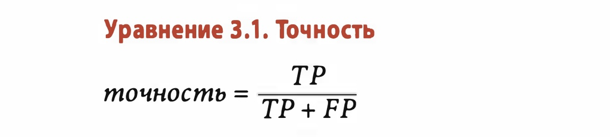

- TP - количество истинно положительных классификаций,
- FP - количество ложноположительных классификаций,

Точность обычно используют наряду с еще одной метрикой под названием **полнота (recall)**, также называемой **чувствительностью (sensetivity)** или **долей истинно положительных классификаций (True Positive Rate - TPR)**: коэффициент положительных образцов, которые корректно обнаруженны классификатором.

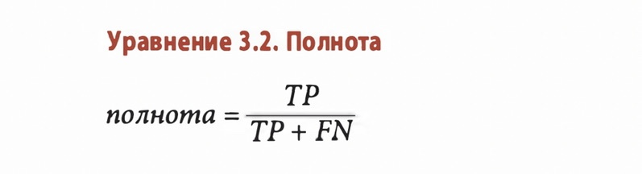

- FN - число ложноотрицательных классификаций.

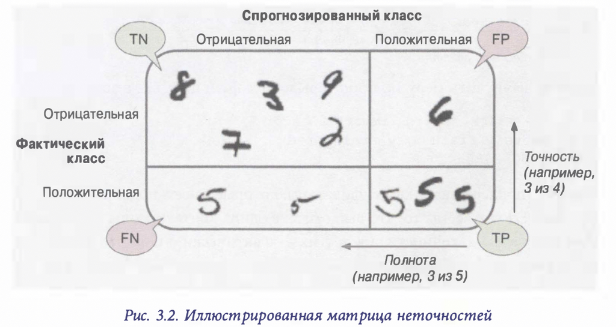

### Точность и полнота

В Scikit-Learn предлагается несколько функций для подсчета метрик классификаторов.

```python
from sklearn.metrics import precision_score, recall_score

print(precision_score(y_train_5, y_train_pred)) # 118 / (118 + 8)
print(recall_score(y_train_5, y_train_pred)) # 118 / (118 + 5)
```

```
0.9512195121951219
0.9512195121951219
```

Точность и полноту часто объединяют в единственную метрику под названием **мера F1 (F1 score)**. **Мера F1** - это *среднее гармоническое (harmonic mean)* точности и полноты. Среднее трактует все значения одинаково, среднее гармоническое придает низким значениям больший вес.

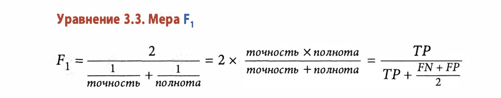

```python
# вычислим меру F1, используя функцию f1_score()
from sklearn.metrics import f1_score

f1_score(y_train_5, y_train_pred)
```

```
0.9512195121951219
```

Мера F1 поддреживает классификаторы, которые имеют подобные точность и полноту.

Увеличение точности снижает полноту и наоборот. Это называется **соотношением точность / полнота (precision/recall tradeoff)**.

### Соотношение точность/полнота

Каким образом класс SGDClassifier принимает свои решения по классификации. Для каждого образца он вычисляет сумму очков на основе **функции решения (decision function)**, и если сумма очков больше какого-то порогового значения, тогда образец приписывается положительному классу, а иначе - отрицательному классу. **Порог принятия решения (decision threshold)** находится на центральной стрелке справа от этого порога четыре истинно положительные классификации и одну ложноположительную классификацию. При таком пороге точность составляет 80% (4 из 5). Но из шести фактических пятерок классификатор обнаруживает только четыре, так что полнота равна 67% (4 из 6).

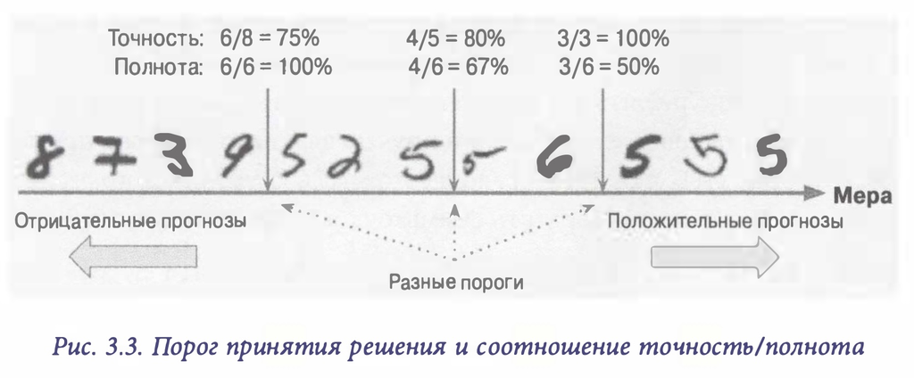

Если поднять порог, увеличивая тем самым точность, но одна истинно положительная классификация становится ложноотрицательной, снижая полноту до 50%. И наоборот, снижение порога увеличивает полноту и сокращает точность.

Библиотека Scikit-Learn не позволяет устанавливать порог напрямую, но предоставляет доступ к суммам очков. Вместо вызова метода **predict()** классификатора можно вызвать метод **decision_function()**, который возвращает сумму очков для каждого образца, и затем вырабатывать прогнозы на основе этих сумм очков, используя любой желаемый порог:

```python
y_scores =sgd_clf.decision_function([some_digit])
y_scores
```

```
array([5745.69302217])
```

Класс SGDClassifier применяет порог равный 0, результат, как метод **predict()**

```python
threshold = 0
y_some_digit_pred = (y_scores > threshold)
y_some_digit_pred
```

```
array([ True])
```

```python
threshold = 200000
y_some_digit_pred = (y_scores > threshold)
y_some_digit_pred
```

```
array([False])
```

Результат подтверждает, что поднятие порога снижает полноту.

Так как же можно решить, какой порог использовать? Сначала понадобится получить суммы очков всех образцов в обучающем наборе, снова применяя функцию **cross_val_predict()**, но на этот раз с указанием того, что вместо прогнозов она должна возвратить суммы очков, управляющие решением:

```python
y_scores = cross_val_predict(sgd_clf, X_train, y_train_5, cv=3, method='decision_function')
```

Теперь с помощью сумм очков можно вычислить точность и полноту для всех возможных порогов, используя функцию **precision_recall_curve()**

```python
from sklearn.metrics import precision_recall_curve

precisions, recalls, thresholds = precision_recall_curve(y_train_5, y_scores)
```

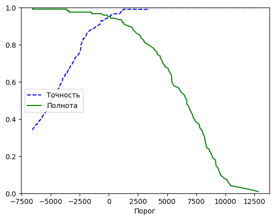

```python
# Используя Matplotlib начертим точность и полноту
def plot_precision_recall_vs_threshold(precisions, recalls, thresholds):
    plt.plot(thresholds, precisions[:-1], "b--", label='Точность')
    plt.plot(thresholds, recalls[:-1], "g-", label='Полнота')
    plt.xlabel('Порог')
    plt.legend(loc='center left')
    plt.ylim([0, 1])

plot_precision_recall_vs_threshold(precisions, recalls, thresholds)
plt.show()
```

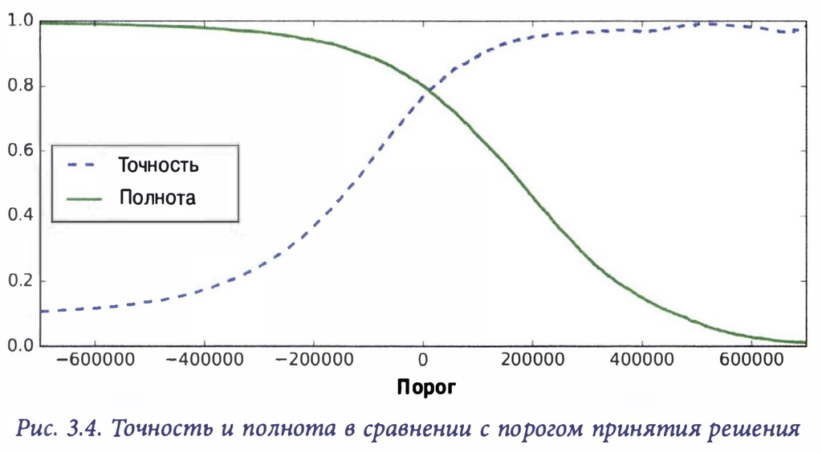

При увеличении порога полнота может только понижаться.

Другой способ выбора хорошего соотношения точность/полнота предусматривает вычерчивание графика точности в сравнении с полнотой:

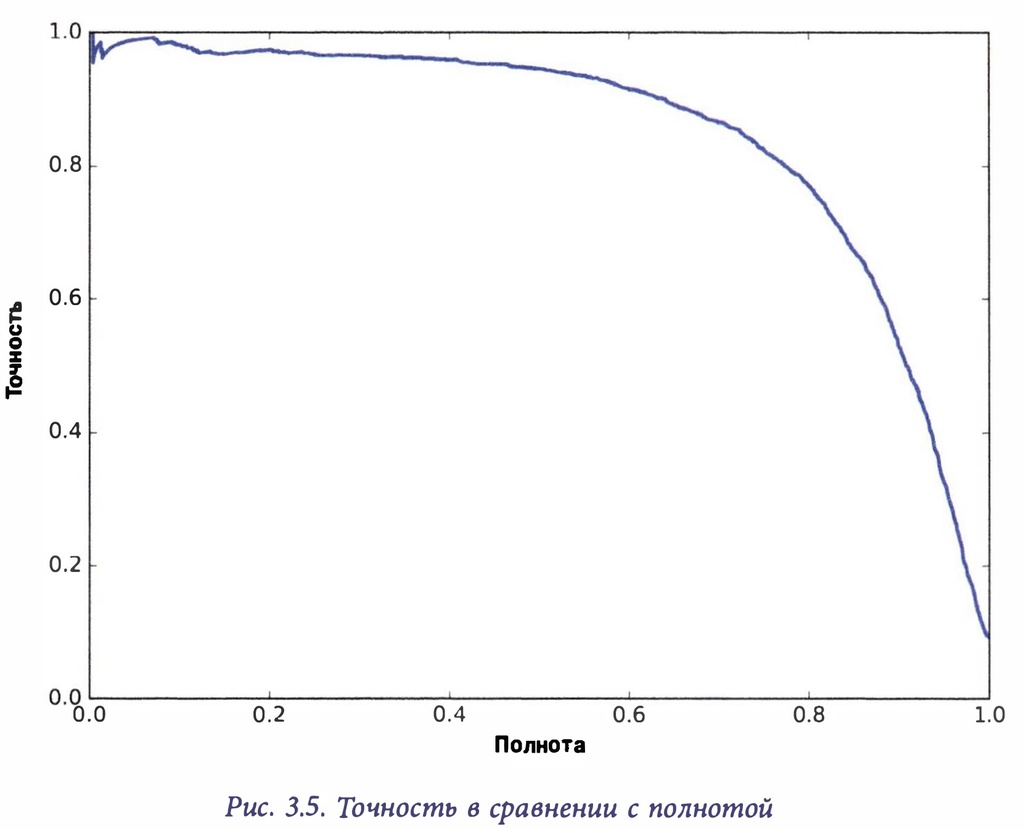

Легко заметить, что точность действительно начинает резко падать пот полноте около 80%. Вероятно, захочется выбрать соотношение точно/полнота прямо перед этим падением.

Чтобы вырабатывать прогнозы, вместо вызова метода **predict()** классификатора можно запустить следующий код

```python
y_train_pred_90 = (y_scores > 1797)
```

```python
precision_score(y_train_5, y_train_pred_90)
```

```
0.990990990990991
```

```python
recall_score(y_train_5, y_train_pred_90)
```

```
0.8943089430894309
```

Замечательно, располагаем классификатором с точностью 99%. Однако, высокоточный классификатор не особенно полезен, если его полнота слишком низкая. То есть создать классификатор с любой желаемой точностью очень легко, но пользы не много от него.

> Если требуют точность 99%, то всегда нужно уточнить, при какой **полноте**.

### Кривая ROC

Кривая **рабочей характеристики приемника (Receiver Operating Characteristic - ROC)** распрастраненный инструмент, применяемый с двоичными классификаторами. Очень похожа на **кривую точность-полноты (precision-recall (PR) curve)**, но вместо вычерчивания точности в сравнении с потнотой кривая ROC изображает **долю истинно положительных классификаций (полнота)** по отношению к **доле ложноположительных классификаций (False Positive Rate - FPR)**. Доля FPR - это пропорция отрицательных образцов, которые некорректно классифицированы как положительные.

FPR = 1 - TNR

- TNR - **доля истино отрицательных классификаций (True Negative Rate)** - пропорция отрицательных образцов, которые были корректно классифицированы как отрицательные.

Доля **TNR** также называется **специфичностью (specificity)**. Таким образом, кривая ROC изображает **чувствительность (sensitivity)** в сравнении с 1 - специфичность.

Для того, чтобы вычертить кривую ROC, сначала необходимо вычислить TPR и FPR для разнообразных значений порога, используя функцию **roc_curve()**:

```python
from sklearn.metrics import roc_curve

fpr, tpr, thresholds = roc_curve(y_train_5, y_scores)
```

Затем можно вычертить график FPR в сравнении с TPR , применяя Matplotlib.

[figure not shown]

```python
def plot_roc_curve(fpr, tpr, label=None):
    plt.plot(fpr, tpr, linewidth=2, label=label)
    plt.plot([0, 1], [0, 1], 'k--')
    plt.axis([0, 1, 0, 1])
    plt.xlabel('False Postitive Rate')
    plt.ylabel('True Positive Rate')

plot_roc_curve(fpr, tpr)
plt.show()
```

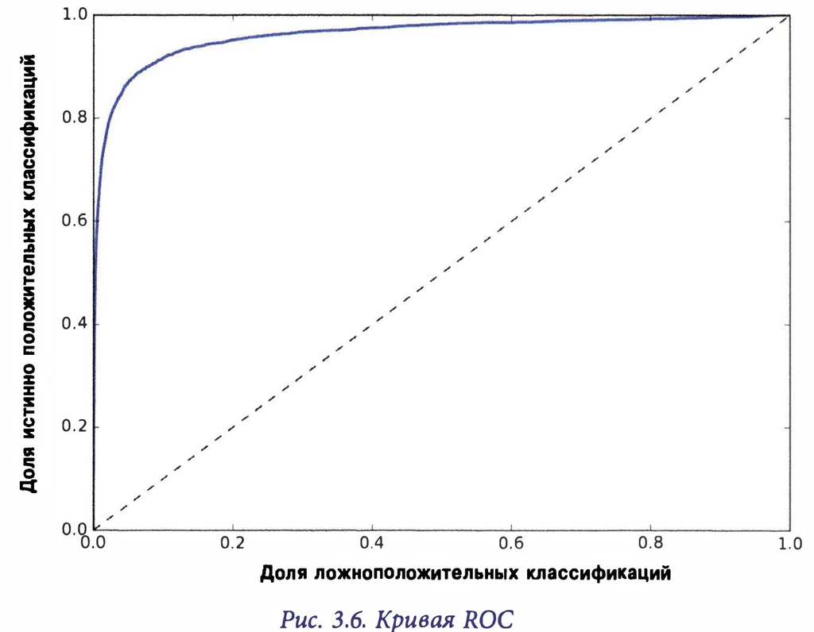

Чем выше полнота (TPR), тем больше классификатор дает ложноположительных классификаций (FPR). Пунктирная линия представляет кривую ROC чисто случайного классификатора; хороший классификатор отстоит от указанной линии настолько далеко, насколько это возможно (стремясь к левому верхнему углу).

Один из способов сравнения классификаторов предусматривает измерение **площади под кривой (Area Under the Curve - AUC)**. Безупречный классификатор будет иметь **площадь под ROC (ROC AUC)**, равную 1, в данном случае чисто случайный классификатор имеет площадь 0.5.

```python
# расчитаем площадь под кривой ROC

from sklearn.metrics import roc_auc_score

roc_auc_score(y_train_5, y_scores)
```

```
0.9968445924013557
```

> Эмпирическое правило: всякий раз, когда положительный класс является редким или ложноположительные классификации заботят больше, чем ложноотрицательные, предпочтение должно отдаваться кривой PR, а иначе - кривой ROC.

Кривая PR дает ясно понять, что классификатор имеет возможности для улучшения.

Построим и обучим классификатор RandomForestClassifier и сравним кривую ROC и показатель ROC AUC с классификатором SGDClassifier.

RandomForestClassifier не имеет метода **decision_function()**. Взамен присутствует метод **predict_proba()**. Данный метод возвращает массив, который содержит строку на образец и столбец на класс, содержащий вероятность того, что заданный образец принадлежит заданному классу.

```python
from sklearn.ensemble import RandomForestClassifier

forest_clf = RandomForestClassifier()
y_probas_forest = cross_val_predict(forest_clf, X_train, y_train_5, cv=3, method='predict_proba')
```

Для вычерчивания кривой ROC нужны показатели, а не вероятности.

```python
y_scores_forest = y_probas_forest[:, 1] # показатель = вероятность положительного класса
fpr_forest, tpr_forest, thresholds_forest = roc_curve(y_train_5, y_scores_forest)
```

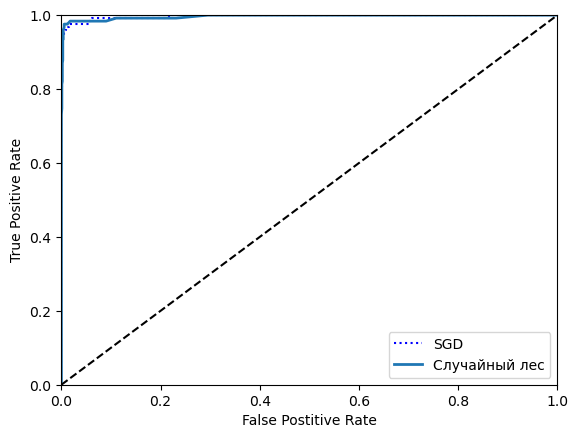

```python
plt.plot(fpr, tpr, "b:", label="SGD")
plot_roc_curve(fpr_forest, tpr_forest, 'Случайный лес')
plt.legend(loc='lower right')
plt.show()
```

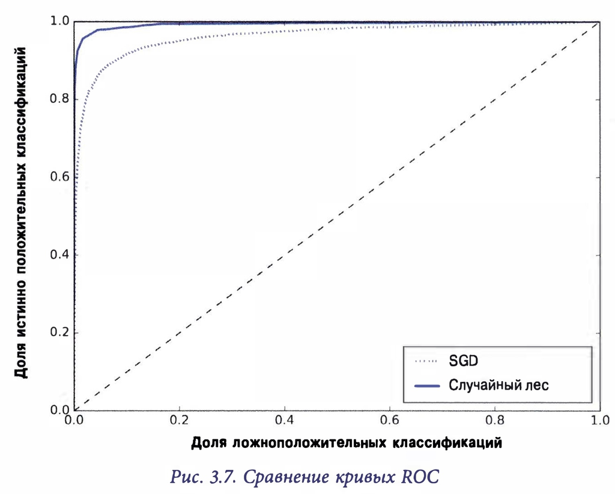

```python
roc_auc_score(y_train_5, y_scores_forest)
```

```
0.9964029863139857
```

```python
y_train_forest_pred = cross_val_predict(forest_clf, X_train, y_train_5, cv=3)
```

```python
precision_score(y_train_5, y_train_forest_pred)
```

```
1.0
```

```python
recall_score(y_train_5, y_train_forest_pred)
```

```
0.8130081300813008
```

Теперь мы знаем как обучать двоичные классификаторы

## Многоклассовая классификация

**Многоклассовые классификаторы (multiclass classifier)**, также называемые **полиномиальными классификаторами (multinomial classifier)** могут различать более двух классов.

Некоторые алгоритмы (случайные леса, наивный байесовский классификатор (naive Bayes classifier))способны обращаться со множеством классов напрямую. Другие (метод опорных векторов, линейный классификатор) являются двоичными классификаторами.

Существуют различные стратегии, используемые для многоклассовой классификации, применяя несколько двоичных классификаторов. Например, **стратегия "один против всех" (one-versus-all - OvA)**, также называемая **"один против всех" (one-vesus-the-rest)**, заключающаяся обучении нескольких двоичных классификаторов, получая от каждого классификатора сумму баллов решения, выбирается класс, чей классификатор выдал наивысший балл.

Другая стратегия предусматривает обучение двоичного классификатора для каждой пары классов. Это называется **стратегией "один против одного" (one-versus-one - OvO)**. Если есть N классов, тогда понадобится обучить Nx(N-1)/2 классификаторов. *Главное преимущество OvO*, что каждый классификатор нуждается в обучении только на части обучающего набора для двух классов, которые он должен различать.

Для большинства алгоритмов двоичной классификации предпочтительной является стратегия OvA. Библиотека Scikit-Learn автоматически инициирует стратегию OvA (за исключением классификаторов методом опорных векторов, для них OvO).

Проверим на классификаторе SGDClassifier:

```python
sgd_clf.fit(X_train, y_train)
sgd_clf.predict([some_digit])
```

```
array([5])
```

За кулисами библиотека Scikit-Learn фактически обучила 10 двоичных классификаторов, получила баллы решений для каждого изображения и выбрала класс с наивысшим баллом.

Она возвращает не сумму баллов на образец, а 10 сумм баллов, по одной на класс:

```python
some_digit_scores = sgd_clf.decision_function([some_digit])
some_digit_scores
```

```
array([[ -6897.3438715 , -11641.1883648 , -13520.80873201,
         -5835.04710375,  -9588.54007853,   1476.13804734,
         -6037.80517573, -10384.51880911,  -7289.5066593 ,
         -8532.68947394]])
```

```python
np.argmax(some_digit_scores)
```

```
5
```

```python
sgd_clf.classes_
```

```
array([0, 1, 2, 3, 4, 5, 6, 7, 8, 9])
```

```python
sgd_clf.classes_[5]
```

```
5
```

Когда классификатор обучен, он сохраняет в своем атрибуте classes_ список целевых классов, упорядоченный по значению.

Заставить Scikit-Learn применять стратегию OvO или OvA, нужно использовать классы OneVsOneClassifier или OneVsRestClassifier. Создать экземпляр класса, передав двоичный классификатор его конструктору.

```python
from sklearn.multiclass import OneVsOneClassifier

ovo_clf = OneVsOneClassifier(SGDClassifier(random_state=42))
ovo_clf.fit(X_train, y_train)
ovo_clf.predict([some_digit])
```

```
array([5])
```

```python
len(ovo_clf.estimators_)
```

```
45
```

```python
# для RandomForestClassifier
forest_clf.fit(X_train, y_train)
forest_clf.predict([some_digit])
```

```
array([5])
```

Можно вызвать метод **predict_proba()**, чтобы получить список вероятностей, с которыми классификатор назначит каждый образец каждому классу.

```python
forest_clf.predict_proba([some_digit])
```

```
array([[0.  , 0.03, 0.01, 0.02, 0.02, 0.83, 0.  , 0.  , 0.06, 0.03]])
```

Оценить созданные классификаторы можно, используя перекрестную проверку.

```python
cross_val_score(sgd_clf, X_train, y_train, cv=3, scoring='accuracy')
```

```
array([0.9375, 0.915 , 0.9375])
```

Чтобы увеличить показатель правильности, может помочь просто масштабирование входных данных.

```python
from sklearn.preprocessing import StandardScaler

scaler = StandardScaler()
X_train_scaled = scaler.fit_transform(X_train.astype(np.float64))
cross_val_score(sgd_clf, X_train_scaled, y_train, cv=3, scoring='accuracy')
```

```
array([0.9475, 0.9425, 0.965 ])
```

## Анализ ошибок

В реальном проекте стоит следовать шагам алгоритма для проекта МО, выбирая лучшие модели и помещая их в список, точно настраивая их гиперпараметры с применением **GridSearchCV**.

В данном разделе предполагается, что наилучшая модель найдена, и нужно найти способ ее усовершенствования. Одним из таким способов является **анализ типов ошибок**.

Первым делом нужно взглянуть на матрицу неточностей, используя функцию **cross_val_predict()** выработаем прогнозы, затем вызовем функцию **confusion_matrix()**.

```python
y_train_pred = cross_val_predict(sgd_clf, X_train_scaled, y_train, cv=3)
conf_m = confusion_matrix(y_train, y_train_pred)
conf_m
```

```
array([[118,   0,   1,   0,   0,   0,   0,   0,   0,   0],
       [  0, 110,   1,   0,   0,   0,   1,   0,   6,   3],
       [  0,   1, 113,   1,   0,   0,   0,   1,   1,   0],
       [  0,   0,   0, 116,   0,   2,   0,   0,   2,   1],
       [  0,   3,   0,   0, 114,   0,   0,   0,   0,   3],
       [  0,   0,   0,   0,   0, 118,   0,   0,   2,   3],
       [  0,   0,   0,   0,   1,   0, 118,   0,   1,   0],
       [  0,   0,   0,   0,   1,   0,   0, 113,   0,   4],
       [  0,   7,   1,   2,   0,   1,   1,   0, 107,   0],
       [  0,   0,   0,   2,   0,   0,   0,   3,   2, 115]])
```

Гораздо удобнее смотреть на представление матрицы в виде изображений, используя функцию **matshow()** из Matplotlib.

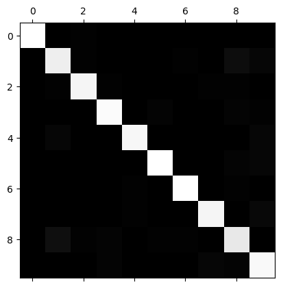

```python
plt.matshow(conf_m, cmap=plt.cm.gray)
plt.show()
```

Итоговая матрица неточностей выглядит неплохо, т.к. большинство изображений расположено на главной диагонали, что означает их корректную классификацию.

Давайте сконцентрируем график на ошибках. Прежде всего, каждое значение в матрице неточностей понадобиться разделить на число изображений в соответствующем классе, чтобы можно было сравнивать частоту ошибок вместо их абсолютного количества.

```python
row_sums = conf_m.sum(axis=1, keepdims=True)
norm_conf_mx = conf_m / row_sums
norm_conf_mx
```

```
array([[0.99159664, 0.        , 0.00840336, 0.        , 0.        ,
        0.        , 0.        , 0.        , 0.        , 0.        ],
       [0.        , 0.90909091, 0.00826446, 0.        , 0.        ,
        0.        , 0.00826446, 0.        , 0.04958678, 0.02479339],
       [0.        , 0.00854701, 0.96581197, 0.00854701, 0.        ,
        0.        , 0.        , 0.00854701, 0.00854701, 0.        ],
       [0.        , 0.        , 0.        , 0.95867769, 0.        ,
        0.01652893, 0.        , 0.        , 0.01652893, 0.00826446],
       [0.        , 0.025     , 0.        , 0.        , 0.95      ,
        0.        , 0.        , 0.        , 0.        , 0.025     ],
       [0.        , 0.        , 0.        , 0.        , 0.        ,
        0.95934959, 0.        , 0.        , 0.01626016, 0.02439024],
       [0.        , 0.        , 0.        , 0.        , 0.00833333,
        0.        , 0.98333333, 0.        , 0.00833333, 0.        ],
       [0.        , 0.        , 0.        , 0.        , 0.00847458,
        0.        , 0.        , 0.95762712, 0.        , 0.03389831],
       [0.        , 0.05882353, 0.00840336, 0.01680672, 0.        ,
        0.00840336, 0.00840336, 0.        , 0.89915966, 0.        ],
       [0.        , 0.        , 0.        , 0.01639344, 0.        ,
        0.        , 0.        , 0.02459016, 0.01639344, 0.94262295]])
```

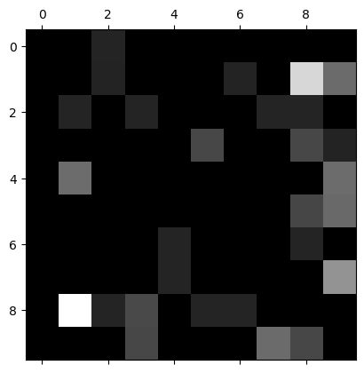

```python
np.fill_diagonal(norm_conf_mx, 0)
plt.matshow(norm_conf_mx, cmap=plt.cm.gray)
plt.show()
```

Анализ индивидуальных ошибок более сложный и затратный по времени и хорошим способом получения информации о том, что и почему делает классификатор.

Нарисуем примеры троек и пятерок (функция **plot_digits()** просто применяя функцию **imshow()**).

[output not shown]

[figure not shown]

```python
def plot_digits(instances, images_per_row=10, **options):
    size = 8
    images_per_row = min(len(instances), images_per_row)
    images = [instance.reshape(size,size) for instance in instances]
    n_rows = (len(instances) - 1) // images_per_row + 1
    row_images = []
    n_empty = n_rows * images_per_row - len(instances)
    images.append(np.zeros((size, size * n_empty)))
    for row in range(n_rows):
        rimages = images[row * images_per_row : (row + 1) * images_per_row]
        row_images.append(np.concatenate(rimages, axis=1))
    image = np.concatenate(row_images, axis=0)
    plt.imshow(image, cmap = mpl.cm.binary, **options)
    plt.axis("off")

cl_a, cl_b = 3, 5
X_aa = X_train[(y_train == cl_a) & (y_train_pred == cl_a)]
X_ab = X_train[(y_train == cl_a) & (y_train_pred == cl_b)]
X_ba = X_train[(y_train == cl_b) & (y_train_pred == cl_a)]
X_bb = X_train[(y_train == cl_b) & (y_train_pred == cl_b)]

plt.figure(figsize=(8,8))
plt.subplot(221); plot_digits(X_aa[:25], images_per_row=5)
plt.subplot(222); plot_digits(X_ab[:25], images_per_row=5)
plt.subplot(223); plot_digits(X_ba[:25], images_per_row=5)
plt.subplot(224); plot_digits(X_bb[:25], images_per_row=5)
plt.show()
```

Большинство неправильно классифицированных изображений выглядят для нас как очевидные ошибки. Причина в том, что используется простой класс SGDClassifier, который представляет собой линейную модель. Он всего лишь назначает каждой точке вес по классу и когда встречает новое изображение, то суммирует взвешенные интенсивности точек, чтобы получить показатель для каждого класса.

Главное отличие между тройками и пятерками - положение маленькой линии, которая соединяет верхнюю линию с нижней дугой.

Данный классификатор крайне чувствителен к сдвигам и поворотам изображений. Следовательно, один из способов сокращения путаницы между тройками и пятерками предусматривает предварительную обработку изображений для гарантии, что они хорошо отцентрированны и не слишком повернуты.

## Многозначная классификация

До сих пор каждый образец всегда назеачался только одному классу. В ряде случаев может быть желательно, чтобы классификатор выдавал множетсво классов для каждого образца.

Система классификации такого рода, которая выдает множество двоичных меток, называется системой **многозначной классификации (multilabel classification)**. Рассмотрим простой пример:

```python
from sklearn.neighbors import KNeighborsClassifier

y_train_large = (y_train >= 7)
y_train_odd = (y_train % 2 == 1)
y_multilabel = np.c_[y_train_large, y_train_odd]

knn_clf = KNeighborsClassifier()
knn_clf.fit(X_train, y_multilabel)
```

```
KNeighborsClassifier()
```

Приведенный код создает массив _y_multilabel_, содержащий две цедевые метки для каждого изображения цифры: первая метка указывает, является ли цифра большой (7, 8 или 9), а вторая - нечетная ли цифра. Создается экземпляр классификатора *KneighborsClassifier* (поддерживающий многозначную классификацию), который обучается с применением массива множества целей.

```python
# выработаем прогноз
knn_clf.predict([some_digit])
```

```
array([[False,  True]])
```

Прогноз верный. Цифра 5 небольшая цирфа и нечетная.

Существует много способов оценки многозначного классификатора и выбор надлежащей метрики крайне зависит от проекта. Один из подходов: определить для каждой отдельной метки меру F1 (любую другую метрику двочных классификаторов) и затем просто подсчитать среднюю сумму очков.

```python
# Средняя мера F1 по всем меткам
y_train_knn_pred = cross_val_predict(knn_clf, X_train, y_multilabel, cv=3)
f1_score(y_multilabel, y_train_knn_pred, average='macro')
```

```
0.9816747378879571
```

Здесь предполагается равная степень важности меток, что может быть и не так.

Простой вариант - дать каждой метке вес, равный ее **поддержке** (т.е. количеству образцов с такой целевой меткой). Чтобы сделать это, нужно установить *average='weighted'*.

Библиотека Scikit-Learn предлагает несколько других вариантов усреднения и метрик многозначных классификаторов.

## Многовыходовая классификация

Последний тип задач это **многовыходовая-многоклассовая классификация (многовыходовая классификация (multioutput classification))**. Это обобщение многозначной классификации, где каждая метка может быть многоклассовой (способна иметь более двух возможных значений).

> Граница между классификацией и регрессией временами размыта, как в рассмотренном примере. Возможно, прогнозирование интенсивности пикселей ближе к регрессии, чем к классификации.

Взяв изображение MNIST и добавив шум к интенсивностям их пикселей с использованием функции *randint()* из NumPy.

```python
noise = np.random.randint(0, 100, (len(X_train), 64))
X_train_mod = X_train + noise
noise = np.random.randint(0, 100, (len(X_test), 64))
X_test_mod = X_test + noise
y_train_mod = X_train
y_test_mod = X_test
```

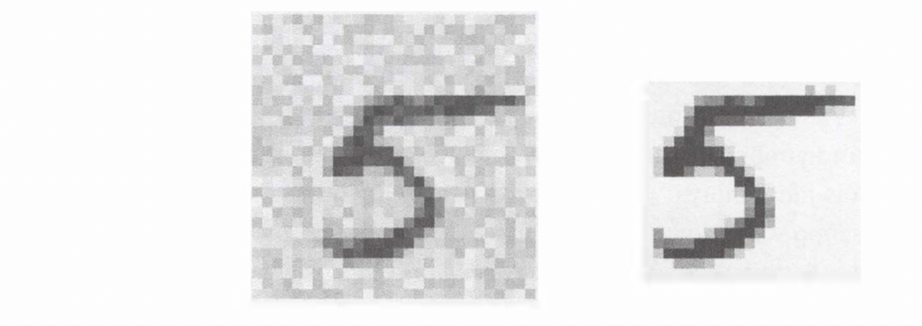

Слева показано зашумленное входное изображение, а справа - чистое целевое изображение. Обучим классификатор и очистим изображение:

```python
knn_clf.fit(X_train_mod, y_train_mod)
clean_digit = knn_clf.predict([X_test_mod[56]])
plot_digit(clean_digit)
```

[output not shown]

[figure not shown]

Теперь, обладаем достаточными знаниями о том, каким образом выбирать хорошие метрики для задач классификации, устанавливать подходящее соотношение точность/полнота, сравнивать классификаторы и как строить эффективные системы классификации для разнооборазных задач.